# MUSSER-GRACE-ADA-HOMEWORK-04

Grace Musser

4/9/2019

```r
library(dplyr)
library(curl)
library(readr)
library(boot)
library(simpleboot)
```

[1] Using the “KamilarAndCooperData.csv” dataset, run a linear regression looking at log(HomeRange_km2) in relation to log(Body_mass_female_mean) and report your β coeffiecients (slope and intercept).

```r
#First, read in the Kamilar and Cooper dataset:
f <- curl("https://raw.githubusercontent.com/difiore/ADA-2019/master/KamilarAndCooperData.csv")
d <- read.csv(f, header = TRUE, sep = ",", stringsAsFactors = TRUE)
head(d)
```

```
##               Scientific_Name          Family          Genus      Species
## 1 Allenopithecus_nigroviridis Cercopithecidae Allenopithecus nigroviridis
## 2         Allocebus_trichotis Cercopithecidae      Allocebus    trichotis
## 3           Alouatta_belzebul        Atelidae       Alouatta     belzebul
## 4             Alouatta_caraya        Atelidae       Alouatta       caraya
## 5            Alouatta_guariba        Atelidae       Alouatta      guariba
## 6           Alouatta_palliata        Atelidae       Alouatta     palliata
##   Brain_Size_Species_Mean Brain_Size_Female_Mean   Brain_size_Ref
## 1                   58.02                  53.70 Isler et al 2008
## 2                      NA                     NA
## 3                   52.84                  51.19 Isler et al 2008
## 4                   52.63                  47.80 Isler et al 2008
## 5                   51.70                  49.08 Isler et al 2008
## 6                   49.88                  48.04 Isler et al 2008
##   Body_mass_male_mean Body_mass_female_mean Mass_Dimorphism
```

[output cut: 69 more lines]

```r
#Create a linear regression model for log (HomeRange_km2) in relation to log(Body_mass_female_mean)
m<-lm(log(d$HomeRange_km2) ~ log(d$Body_mass_female_mean))
m
```

```
##
## Call:
## lm(formula = log(d$HomeRange_km2) ~ log(d$Body_mass_female_mean))
##
## Coefficients:
##                  (Intercept)  log(d$Body_mass_female_mean)
##                       -9.441                         1.036
```

```r
summary(m) #report coefficients
```

```
##
## Call:
## lm(formula = log(d$HomeRange_km2) ~ log(d$Body_mass_female_mean))
##
## Residuals:
##     Min      1Q  Median      3Q     Max
## -3.3929 -0.9433 -0.0126  1.0944  3.6826
##
## Coefficients:
##                              Estimate Std. Error t value Pr(>|t|)
## (Intercept)                  -9.44123    0.67293  -14.03   <2e-16 ***
## log(d$Body_mass_female_mean)  1.03643    0.08488   12.21   <2e-16 ***
## ---
## Signif. codes:  0 '***' 0.001 '**' 0.01 '*' 0.05 '.' 0.1 ' ' 1
##
## Residual standard error: 1.423 on 135 degrees of freedom
##   (76 observations deleted due to missingness)
## Multiple R-squared:  0.5248, Adjusted R-squared:  0.5213
## F-statistic: 149.1 on 1 and 135 DF,  p-value: < 2.2e-16
```

```r
confint(m) #get confidence intervals for the model
```

```
##                                    2.5 %    97.5 %
## (Intercept)                  -10.7720889 -8.110374
## log(d$Body_mass_female_mean)   0.8685707  1.204292
```

[2] Then, use bootstrapping to sample from your data 1000 times with replacement, each time fitting the same model and calculating the appropriate coefficients. This generates a sampling distribution for each β coefficient. Plot a histogram of these sampling distributions.

```r
n <- length(d[,1]) #make sure that n matches the length of the dataset
t <- 1000 #sample times
boots <- d[sample(nrow(d), n, replace = TRUE), ] #create bootstrap with replacement
str(boots)
```

```
## 'data.frame':    213 obs. of  44 variables:
##  $ Scientific_Name        : Factor w/ 213 levels "Allenopithecus_nigroviridis",..: 41 197 192 196 200 117 173 45 28 114 ...
##  $ Family                 : Factor w/ 14 levels "Atelidae","Cebidae",..: 2 2 2 2 14 11 3 2 13 11 ...
##  $ Genus                  : Factor w/ 65 levels "Allenopithecus",..: 14 59 58 59 62 34 53 14 11 34 ...
##  $ Species                : Factor w/ 198 levels "abelii","aethiops",..: 4 167 129 137 23 111 109 197 82 57 ...
##  $ Brain_Size_Species_Mean: num  65.45 24.14 9.48 25.07 3.16 ...
##  $ Brain_Size_Female_Mean : num  63.24 24.02 9.62 25.52 3.17 ...
##  $ Brain_size_Ref         : Factor w/ 2 levels "","Isler et al 2008": 2 2 2 2 2 1 2 2 1 2 ...
##  $ Body_mass_male_mean    : num  3180 855 380 897 128 ...
##  $ Body_mass_female_mean  : num  2290 742 370 680 123 ...
##  $ Mass_Dimorphism        : num  1.39 1.15 1.03 1.32 1.04 ...
##  $ Mass_Ref               : Factor w/ 3 levels "","Isler et al 2008",..: 2 2 2 2 2 1 2 2 3 2 ...
##  $ MeanGroupSize          : num  25.1 38 NA 55.3 NA NA 14.5 NA NA 1 ...
##  $ AdultMales             : num  3.8 4.3 NA 10 NA NA 1 NA NA 1 ...
##  $ AdultFemale            : num  6.5 7.9 NA 8.9 NA NA 6 NA NA 1 ...
```

[output cut: 30 more lines]

```r
b0 <- rep(0,t) #beta0 values vector
b1 <- rep(0,t) #beta1 values vector

for (i in 1:t){
  boots <- d[sample(nrow(d), n, replace = TRUE), ] #boottrap with replacement
  m <- lm(data = boots, formula = log(HomeRange_km2) ~ log(Body_mass_female_mean)) #define model
  b0[i] <- m$coefficients[1] #add model coefficients to vectors
  b1[i] <- m$coefficients[2]
  }


head(b1)
```

```
## [1] 0.9424441 1.0181150 0.8242783 0.9056471 1.1780627 1.0723345
```

```r
head(b0)
```

```
## [1]  -8.760742  -9.253997  -7.654825  -8.413823 -10.650571  -9.695517
```

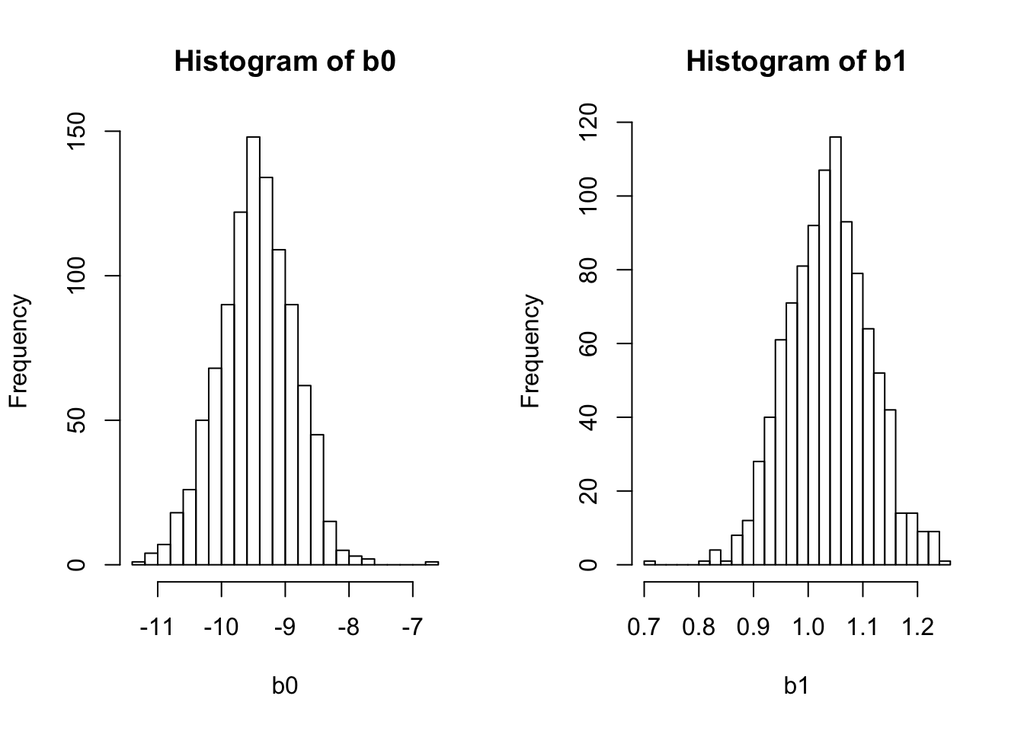

```r
par(mfrow = c(1,2)) #plot histogram
hist(b0, breaks = 20)
hist(b1, breaks = 20)
```

```r
par(mfrow = c(1,1))
```

[3] Estimate the standard error for each of your β coefficients as the standard deviation of the sampling distribution from your bootstrap.

```r
SEb0 <- sd(b0) #get standard error for beta coefficients
SEb0
```

```
## [1] 0.5848809
```

```r
SEb1 <- sd(b1)
SEb1
```

```
## [1] 0.07536687
```

[4] Also determine the 95% CI for each of your β coefficients based on the appropriate quantiles from your sampling distribution.

```r
b0_CI_upper <- mean(b0) + qnorm(0.975) * SEb0 #get confidence errors based on quantiles using means of betas
b0_CI_lower <- mean(b0) - qnorm(0.975) * SEb0
b0_CI_upper
```

```
## [1] -8.305484
```

```r
b0_CI_lower
```

```
## [1] -10.59817
```

```r
b1_CI_upper <- mean(b1) + qnorm(0.975) * SEb1
b1_CI_lower <- mean(b1) - qnorm(0.975) * SEb1
b1_CI_lower
```

```
## [1] 0.8901114
```

```r
b1_CI_upper
```

```
## [1] 1.185544
```

[5] How does your answer to part [3] compare to the SE estimated from your entire dataset using the formula for standard error implemented in lm()?

[6] How does your answer to part [4] compare to the 95% CI estimated from your entire dataset?

EXTRA CREDIT: + 2

Write a FUNCTION that takes as its arguments a dataframe (“d”), a linear model (“m”, as a character string, e.g., “logHR~logBM”), a user-defined confidence interval level (“conf.level”) with default = 0.95, and a number of bootstrap replicates (“n”, with default = 1000). Your function should return a dataframe that includes: beta coefficient names; beta coefficients, standard errors, and upper and lower CI limits for the linear model based on your entire dataset; and mean beta coefficient estimates, SEs, and CI limits for those coefficients based on your bootstrap.

```r
f<-function(d, m, conf.level=0.95, t=1000){
  m<-lm(log(d$HomeRange_km2) ~ log(d$Body_mass_female_mean))
  s<-summary(m)
  ci<-confint(m)
  dsample <- d[sample(nrow(d), n, replace = T), ]
  head(dsample)
  str(dsample)
  n <- length(d[,1]) #make sure that n matches the length of the dataset
  boots <- d[sample(nrow(d), n, replace = TRUE), ] #create bootstrap with replacement
  str(boots)
  b0 <- rep(0,t) #beta0 values vector
  b1 <- rep(0,t) #beta1 values vector
  for (i in 1:t){
    boots <- d[sample(nrow(d), n, replace = TRUE), ] #boottrap with replacement
    m <- lm(data = boots, formula = log(HomeRange_km2) ~ log(Body_mass_female_mean)) #define model
    b0[i] <- m$coefficients[1] #add model coefficients to vectors
    b1[i] <- m$coefficients[2]
    }
  SEb0 <- sd(b0) #get standard error for beta coefficients
  SEb0
  SEb1 <- sd(b1)
  SEb1
  b0_CI_upper <- mean(b0) + qnorm(0.975) * SEb0 #get confidence errors based on quantiles using means of betas
  b0_CI_lower <- mean(b0) - qnorm(0.975) * SEb0
  b0CI<-c(b0_CI_upper, b0_CI_lower)
  b1_CI_upper <- mean(b1) + qnorm(0.975) * SEb1
  b1_CI_lower <- mean(b1) - qnorm(0.975) * SEb1
  b0CI<-c(b1_CI_lower, b1_CI_upper)
  print(s)
  print(ci)
  print(b0CI, b0CI)
  print(SEb0)
  print(SEb1)
  }
```

```r
f(d, m, conf.level, n)
```

```
## 'data.frame':    213 obs. of  44 variables:
##  $ Scientific_Name        : Factor w/ 213 levels "Allenopithecus_nigroviridis",..: 147 10 66 140 38 98 190 22 107 31 ...
##  $ Family                 : Factor w/ 14 levels "Atelidae","Cebidae",..: 8 2 3 3 2 10 2 9 8 13 ...
##  $ Genus                  : Factor w/ 65 levels "Allenopithecus",..: 43 4 16 38 13 28 58 7 29 11 ...
##  $ Species                : Factor w/ 198 levels "abelii","aethiops",..: 43 31 196 174 92 18 112 134 147 183 ...
##  $ Brain_Size_Species_Mean: num  NA NA 61.5 153.9 NA ...
##  $ Brain_Size_Female_Mean : num  NA NA 57.2 146.6 NA ...
##  $ Brain_size_Ref         : Factor w/ 2 levels "","Isler et al 2008": 1 1 2 2 1 1 2 2 2 2 ...
##  $ Body_mass_male_mean    : num  7790 NA 3910 34400 NA ...
##  $ Body_mass_female_mean  : num  7620 NA 2870 12800 NA ...
##  $ Mass_Dimorphism        : num  1.02 NA 1.36 2.69 NA ...
##  $ Mass_Ref               : Factor w/ 3 levels "","Isler et al 2008",..: 3 1 2 2 1 1 2 2 2 2 ...
##  $ MeanGroupSize          : num  NA 3 NA NA 5 3 NA 3.5 NA 4.8 ...
##  $ AdultMales             : num  NA 1 NA NA 2 NA NA 1 1 1 ...
##  $ AdultFemale            : num  NA 1 NA NA 1 NA NA 1 1 1 ...
```

[output cut: 101 more lines]